# NLP Week 5- Sentiment Analysis on Unabomber

Emma Moughan

02-23-2026

# Instructions

1. Pro CSS (high contrast)
2. Give an updated report/sentiment analysis on the variables of interest on Unabomber  
   2a. Improve cleaning genie (change name to emma_genie; make it so you’re happier with it)  
   2b. Generate table for raw Unabomber text and cleaning genie Unabomber text  
   2c. State hypothesis/hypotheses (why four variables are important)  
   2d. Run 4 variables  
   2e. Summarize with plots for visualization  
   2f. Give a written report

## Reading in Data

```r
# reading in Unabomber Manifesto
unabomb <- as.character(readtext("https://raw.githubusercontent.com/Reilly-ConceptsCognitionLab/reillylab_publicdata/main/unabomber_manifesto.txt"))
# print first few lines
cat(unabomb[1:50], sep = "\n")
```

```
## INDUSTRIAL SOCIETY AND ITS FUTURE
##
## Introduction
##
## 1. The Industrial Revolution and its consequences have been a disaster for the
##    human race. They have greatly increased the life-expectancy of those of us
##    who live in “advanced” countries, but they have destabilized society, have
##    made life unfulfilling, have subjected human beings to indignities, have led
##    to widespread psychological suffering (in the Third World to physical
##    suffering as well) and have inflicted severe damage on the natural world. The
##    continued development of technology will worsen the situation. It will
##    certainly subject human beings to greater indignities and inflict greater
##    damage on the natural world, it will probably lead to greater social
##    disruption and psychological suffering, and it may lead to increased physical
##    suffering even in “advanced” countries.
##
## 2. The industrial-technological system may survive or it may break down. If it
##    survives, it MAY eventually achieve a low level of physical and psychological
##    suffering, but only after passing through a long and very painful period of
##    adjustment and only at the cost of permanently reducing human beings and many
##    other living organisms to engineered products and mere cogs in the social
##    machine. Furthermore, if the system survives, the consequences will be
##    inevitable: There is no way of reforming or modifying the system so as to
##    prevent it from depriving people of dignity and autonomy.
##
## 3. If the system breaks down the consequences will still be very painful. But
##    the bigger the system grows the more disastrous the results of its breakdown
##    will be, so if it is to break down it had best break down sooner rather than
##    later.
##
## 4. We therefore advocate a revolution against the industrial system. This
##    revolution may or may not make use of violence; it may be sudden or it may be
##    a relatively gradual process spanning a few decades. We can’t predict any of
##    that. But we do outline in a very general way the measures that those who
##    hate the industrial system should take in order to prepare the way for
##    a revolution against that form of society. This is not to be a POLITICAL
##    revolution. Its object will be to overthrow not governments but the economic
##    and technological basis of the present society.
##
## 5. In this article we give attention to only some of the negative developments
```

[output cut: 3315 more lines]

[output not shown]

```r
# making raw file a corpus
corpus <- corpus(unabomb)

# other data
load(file = "data/SMART_stops.rda")  # additional stopwords if needed
```

## Cleaning Genie

```r
emma_genie <- function(input, text_col = NULL, replacements = T, omit_stops = T, lemmatize = T) {
  # load in necessary libraries for the cleaning genie function
  library(dplyr)
  library(tidyr)
  library(stringr)
  library(stringi)

  # different input types
  if(is.character(input) & is.null(text_col)) {
    df <- data.frame(text = input, stringsAsFactors = F)
    text_col <- "text"
  } else if (is.data.frame(input)) {
    df <- input
    if (is.null(text_col)) stop(paste("Provide text_col when input is a dataframe."))
    } else {
      stop(paste("Input must be a character vector or a dataframe"))
    }

  # if the column specified by "wordcol" does not exist in "df", show an error message
  if (!text_col %in% names(df)) {
    stop(paste("Column", text_col, "not found in dataframe"))
  }

  # load contraction & stop word corpora
  load(url("https://github.com/Reilly-ConceptsCognitionLab/reillylab_publicdata/blob/main/Temple_stops25.rda?raw=true"))
  load(url("https://github.com/Reilly-ConceptsCognitionLab/reillylab_publicdata/blob/main/replacements_25.rda?raw=true"))

  # creates an ID column, selects text column from text_col, forces it into a character, fixes any encoding issues, converts it to UTF-8, and changes all text to lowercase
  prep <- df |>
    mutate(
      ID = factor(seq_len(nrow(df))),

      initial_split = tryCatch(
        stri_enc_toutf8(
          as.character(.data[[text_col]]),
          is_unknown_8bit = T,
          validate = T
          ),
        error = function(e) {
          stri_encode(
            as.character(.data[[text_col]]),
            to = "UTF-8"
            )
          }
        ) |> tolower()
      )

  # preserve NA values and standardize apostrophes to the ASCII apostrophe to ensure that code doesn't break further down the pipeline because of variance in apostrophe types
   prep <- prep |>
    mutate(
      initial_split = ifelse(
      is.na(initial_split),
      NA_character_,
      stri_replace_all_regex(initial_split, "[\u2018\u2019\u02BC\u201B\uFF07\u0092\u0091\u0060\u00B4\u2032\u2035]", "'")
      )
    )

   # splits text into individual tokens by word and puts them in row format, converts blank tokens to NA, removes the original text column (in left to right format)
   prep <- prep |>
     separate_rows(initial_split, sep = "[[:space:]]+") |>

     mutate(
       initial_split = ifelse(
       is.na(initial_split) | stri_isempty(initial_split),
       NA_character_,
       initial_split)
       ) |>

     select(-all_of(text_col))

   # PIECE OF GENIE THAT WILL BE EDITED BASED ON CLEANING NEEDS
   # removes punctuation, special characters, and whitespace. keeps apostrophes for contraction expansion purposes and hyphenated words to preserve their meaning.
   prep <- prep |>
     mutate(
       clean = initial_split,

       clean = ifelse(
         is.na(clean),
         NA_character_,
         stri_replace_all_regex(clean, "[^a-zA-Z0-9-']", "")
         ),

       clean = ifelse(
         is.na(clean),
         NA_character_,
         str_squish(clean)
         ),

       clean = ifelse(
         is.na(clean),
         NA_character_,
         stri_replace_all_regex(clean, "[^a-z'-]", "")
         )
       )

   # expands contractions with keeping all other words and preserving NAs
   if(replacements) {
     map <- setNames(
       tolower(replacements_25$replacement),
       tolower(replacements_25$word)
     )

     prep <- prep |>
       mutate(
         is_replacement = ifelse(
           is.na(clean),
           NA_character_,
           dplyr::recode(tolower(clean), !!!map, .default = clean)
         )
       ) |>
       select(-is_replacement)
   }

   # splits new clean version into tokens and forces individual words into rows; removes all apostrophes
   prep <- prep |>
     separate_rows(clean, sep = "[[:space:]]+", convert = T) |>
     mutate(
       clean = ifelse(
         is.na(clean) | stri_isempty(clean),
         NA_character_,
         stri_replace_all_regex(clean, "'", "")
       ),
       ID_post_split = seq_len(dplyr::n())
     )

   # lemmatizes words (basic dictionary form)
   if(lemmatize) {
     prep <- prep |>
       mutate(
         clean = ifelse(
           is.na(clean),
           NA_character_,
           textstem::lemmatize_strings(clean)
         )
       )
   }

   # removes stop words and flags where they were with NAs
   if (omit_stops) {
     stopwords <- tolower(Temple_stops25$word)

     prep <- prep |>
       mutate(
         is_stopword = ifelse(
           is.na(clean),
           NA,
           clean %in% stopwords
         ),
         clean = ifelse(
           is_stopword,
           NA_character_,
           clean
         )
       ) |>
       select(-is_stopword)
   }

   return(prep)
}

# clean unabomb
clean <- emma_genie(unabomb)
```

## Raw vs. Cleaned Text

```r
print(clean[, c("clean", "initial_split")])
```

```
## # A tibble: 34,520 × 2
##    clean        initial_split
##    <chr>        <chr>
##  1 industrial   industrial
##  2 society      society
##  3 <NA>         and
##  4 <NA>         its
##  5 future       future
##  6 introduction introduction
##  7 <NA>         1.
##  8 <NA>         the
##  9 industrial   industrial
## 10 revolution   revolution
## # ℹ 34,510 more rows
```

## Hypothesis

Because of the nature of manifestos, I am making an inference that the Unabomber made some sort of “call to action” towards the end of his document. This call to action will be measured via emotion components, specifically higher guilt, arousal, and anger values, and via semantic visualization, where the words will have more semantic clustering due to their similarity and content.

## Four Variables

```r
# load in data
load(url("https://github.com/Reilly-ConceptsCognitionLab/reillylab_publicdata/blob/main/lookup_Jul25.rda?raw=true"))

# create dataframe
lookup_db <- lookup_Jul25
colnames(lookup_db)
```

```
##  [1] "word"                    "emo_anger"
##  [3] "emo_anger_rescale"       "emo_anxiety"
##  [5] "emo_anxiety_rescale"     "emo_arousal_b24"
##  [7] "emo_arousal_b24_rescale" "emo_boredom"
##  [9] "emo_boredom_rescale"     "emo_confusion"
## [11] "emo_confusion_rescale"   "emo_excitement"
## [13] "emo_excitement_rescale"  "emo_guilt"
## [15] "emo_guilt_rescale"       "emo_happiness"
## [17] "emo_happiness_rescale"   "emo_intensity"
## [19] "emo_intensity_recale"    "emo_sadness"
## [21] "emo_sadness_rescale"     "emo_trust"
## [23] "emo_trust_rescale"       "emo_valence_b24"
## [25] "emo_valence_b24_rescale" "lex_AoA"
## [27] "lex_AoA_rescale"         "lex_freqlg10"
## [29] "lex_freqlg10_rescale"    "lex_n_morphemes"
## [31] "lex_n_senses"            "lex_n_senses_rescale"
## [33] "phon_n_lett"             "phon_nsyll"
## [35] "sem_auditory"            "sem_auditory_rescale"
## [37] "sem_cnc_b24"             "sem_cnc_b24_rescale"
## [39] "sem_cnc_v2013"           "sem_cnc_v2013_rescale"
## [41] "sem_diversity"           "sem_diversity_rescale"
## [43] "sem_neighbors"           "sem_neighbors_rescale"
## [45] "sem_visual"              "sem_visual_rescale"
```

```r
str(lookup_db)
```

```
## 'data.frame':    156203 obs. of  46 variables:
##  $ word                   : chr  "a" "aa" "aaa" "aaaa" ...
##  $ emo_anger              : num  0.019 -0.0256 -0.0901 -0.1093 -0.0249 ...
##  $ emo_anger_rescale      : num  2.58 2.29 1.87 1.74 2.29 ...
##  $ emo_anxiety            : num  -0.0491 -0.1282 -0.0491 -0.1137 -0.0472 ...
##  $ emo_anxiety_rescale    : num  2.05 1.52 2.05 1.62 2.06 ...
##  $ emo_arousal_b24        : num  1.01 3.02 NA NA NA NA NA 5.11 NA NA ...
##  $ emo_arousal_b24_rescale: num  0.133 2.364 NA NA NA ...
##  $ emo_boredom            : num  0.0424 -0.0838 0.0168 -0.0445 -0.0321 -0.0142 0.0068 -0.0594 -0.0417 -0.0092 ...
##  $ emo_boredom_rescale    : num  2.7 1.87 2.53 2.13 2.21 ...
##  $ emo_confusion          : num  -0.0686 -0.1565 -0.0887 -0.0615 0.0184 ...
##  $ emo_confusion_rescale  : num  1.3 0.67 1.16 1.35 1.93 ...
##  $ emo_excitement         : num  -0.0381 0.0135 -0.0681 0.0001 -0.0459 -0.0592 0.0362 -0.0007 0.0471 0.0606 ...
##  $ emo_excitement_rescale : num  2.55 2.87 2.36 2.79 2.5 ...
##  $ emo_guilt              : num  0.0634 0.028 0.0089 -0.0154 -0.016 0.0053 0.0215 0.0194 0.0447 -0.0286 ...
```

[output cut: 36 more lines]

```r
# create subset to analyze
lookup_sub <- lookup_db |>
    select(word, emo_anger_rescale, emo_arousal_b24_rescale, emo_guilt_rescale, sem_visual_rescale)
str(lookup_sub)
```

```
## 'data.frame':    156203 obs. of  5 variables:
##  $ word                   : chr  "a" "aa" "aaa" "aaaa" ...
##  $ emo_anger_rescale      : num  2.58 2.29 1.87 1.74 2.29 ...
##  $ emo_arousal_b24_rescale: num  0.133 2.364 NA NA NA ...
##  $ emo_guilt_rescale      : num  2.75 2.52 2.39 2.23 2.22 ...
##  $ sem_visual_rescale     : num  4.37 NA NA NA NA ...
```

```r
# merge cleaned unabomber text with lookup subset
combined <- clean |>
    left_join(lookup_sub, by = c(clean = "word")) |>
    select(-ID)
```

## Line Plots - Over Time

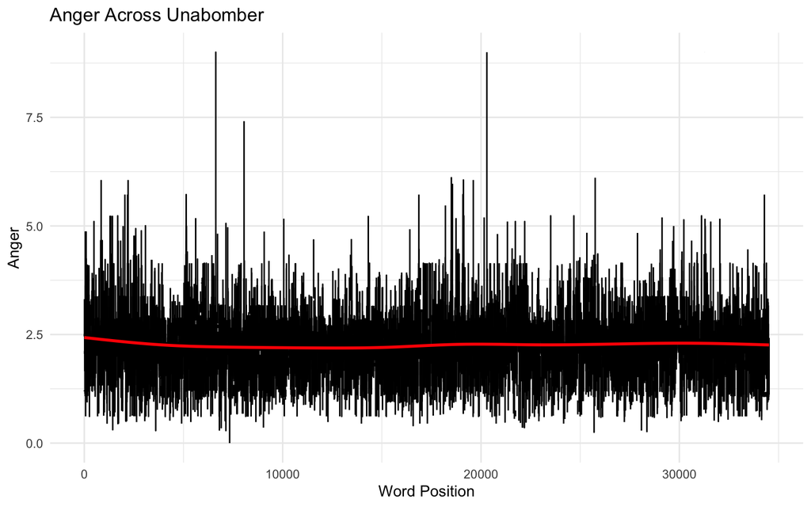

```r
# anger
ggplot(combined, aes(x = ID_post_split, y = emo_anger_rescale)) + geom_line() + geom_smooth(se = F,
    color = "red") + labs(x = "Word Position", y = "Anger", title = "Anger Across Unabomber") +
    theme_minimal()
```

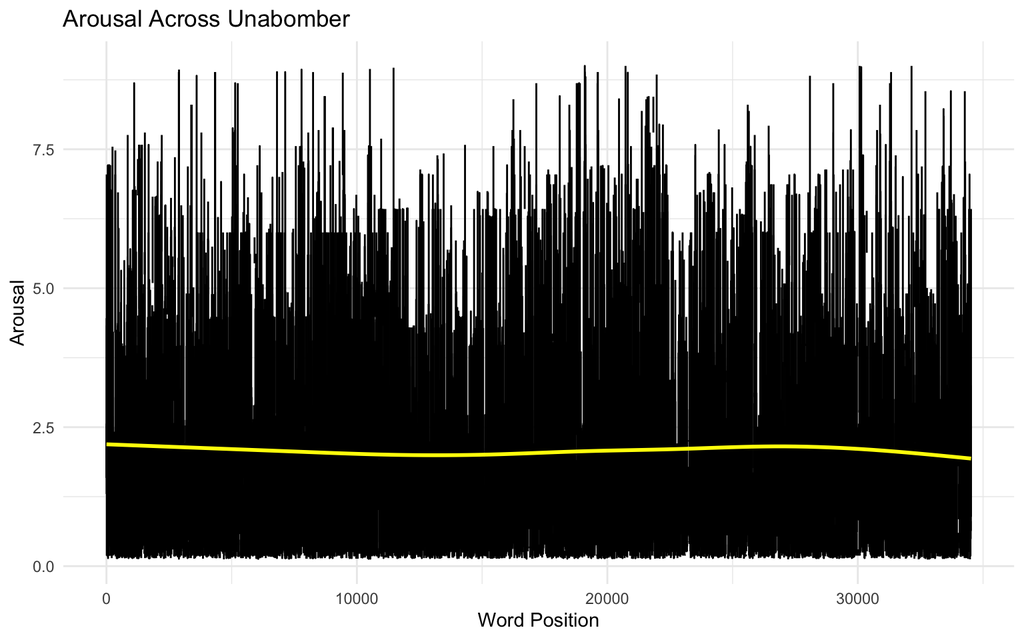

```r
# arousal
ggplot(combined, aes(x = ID_post_split, y = emo_arousal_b24_rescale)) + geom_line() +
    geom_smooth(se = F, color = "yellow") + labs(x = "Word Position", y = "Arousal",
    title = "Arousal Across Unabomber") + theme_minimal()
```

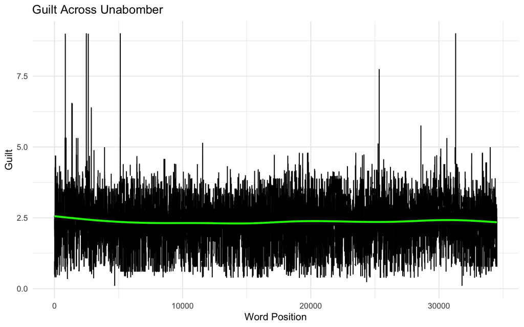

```r
# guilt
ggplot(combined, aes(x = ID_post_split, y = emo_guilt_rescale)) + geom_line() + geom_smooth(se = F,
    color = "green") + labs(x = "Word Position", y = "Guilt", title = "Guilt Across Unabomber") +
    theme_minimal()
```

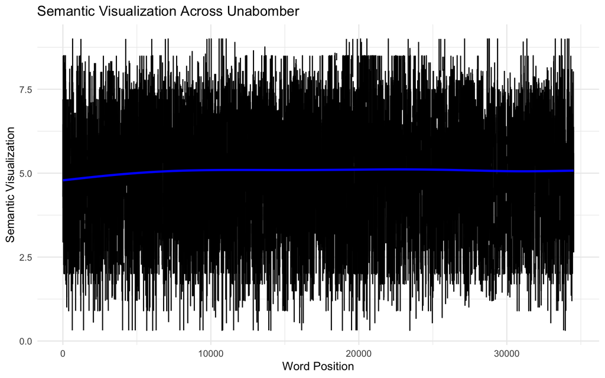

```r
# semantic visualization
ggplot(combined, aes(x = ID_post_split, y = sem_visual_rescale)) + geom_line() +
    geom_smooth(se = F, color = "blue") + labs(x = "Word Position", y = "Semantic Visualization",
    title = "Semantic Visualization Across Unabomber") + theme_minimal()
```

## Lexical Dispersion Plots - Individual Words

```r
# extract top 5 highest scoring words in each category
top_5_anger <- combined[order(combined$emo_anger_rescale, decreasing = T, na.last = NA)[1:10],
    ]  # showing 10 to extract individual words
top_5_anger
```

| initial_split | clean | ID_post_split | emo_anger_rescale | emo_arousal_b24_rescale | emo_guilt_rescale | sem_visual_rescale |
| --- | --- | --- | --- | --- | --- | --- |
| anger, | anger | 6629 | 9.00 | 6.99 | 4.23 | 4.40 |
| anger | anger | 20295 | 9.00 | 6.99 | 4.23 | 4.40 |
| anger, | anger | 31272 | 9.00 | 6.99 | 4.23 | 4.40 |
| anger | anger | 31273 | 9.00 | 6.99 | 4.23 | 4.40 |
| angry. | angry | 7905 | 7.41 | 7.25 | 3.69 | 4.75 |
| angry, | angry | 8053 | 7.41 | 7.25 | 3.69 | 4.75 |
| resentment | resentment | 32278 | 7.19 | 5.66 | 4.35 | 4.23 |
| dissatisfaction. | dissatisfaction | 18505 | 6.11 | 4.86 | 4.04 | 3.90 |
| dissatisfaction | dissatisfaction | 25755 | 6.11 | 4.86 | 4.04 | 3.90 |
| hatred, | hatred | 848 | 6.06 | 7.76 | 4.05 | 5.22 |

```r
top_5_arousal <- combined[order(combined$emo_arousal_b24_rescale, decreasing = T,
    na.last = NA)[1:10], ]  # showing 10 to extract individual words
top_5_arousal
```

| initial_split | clean | ID_post_split | emo_anger_rescale | emo_arousal_b24_rescale | emo_guilt_rescale | sem_visual_rescale |
| --- | --- | --- | --- | --- | --- | --- |
| rape, | rape | 19099 | 2.94 | 9.00 | 3.95 | 5.67 |
| guns | gun | 20725 | 3.43 | 9.00 | 3.45 | 7.83 |
| gun | gun | 30071 | 3.43 | 9.00 | 3.45 | 7.83 |
| gun | gun | 32144 | 3.43 | 9.00 | 3.45 | 7.83 |
| ���genocide,��� | genocide | 30136 | 3.97 | 8.98 | 4.43 | 5.78 |
| kill | kill | 11463 | 3.37 | 8.97 | 3.77 | 4.95 |
| kill | kill | 16999 | 3.37 | 8.97 | 3.77 | 4.95 |
| kill | kill | 17047 | 3.37 | 8.97 | 3.77 | 4.95 |
| terrorists. | terrorist | 32907 | 3.89 | 8.97 | 4.21 | 6.51 |
| bomb? | bomb | 10520 | 3.69 | 8.94 | 3.52 | 5.72 |

```r
top_5_guilt <- combined[order(combined$emo_guilt_rescale, decreasing = T, na.last = NA)[1:20],
    ]  # showing 20 to extract individual words
top_5_guilt
```

| initial_split | clean | ID_post_split | emo_anger_rescale | emo_arousal_b24_rescale | emo_guilt_rescale | sem_visual_rescale |
| --- | --- | --- | --- | --- | --- | --- |
| guilt, | guilt | 846 | 4.32 | 5.57 | 9.00 | 3.00 |
| guilt, | guilt | 2437 | 4.32 | 5.57 | 9.00 | 3.00 |
| guilt, | guilt | 2485 | 4.32 | 5.57 | 9.00 | 3.00 |
| guilt, | guilt | 2638 | 4.32 | 5.57 | 9.00 | 3.00 |
| guilt, | guilt | 5134 | 4.32 | 5.57 | 9.00 | 3.00 |
| guilt, | guilt | 31302 | 4.32 | 5.57 | 9.00 | 3.00 |
| guilty | guilty | 9310 | 4.56 | 5.70 | 8.45 | 3.38 |
| blame | blame | 1788 | 4.84 | 4.62 | 7.75 | 3.33 |
| blame | blame | 25309 | 4.84 | 4.62 | 7.75 | 3.33 |
| blame | blame | 25318 | 4.84 | 4.62 | 7.75 | 3.33 |
| blaming | blame | 25336 | 4.84 | 4.62 | 7.75 | 3.33 |
| faults | fault | 1355 | 4.35 | 1.73 | 6.54 | 4.07 |
| faults | fault | 1389 | 4.35 | 1.73 | 6.54 | 4.07 |
| faults | fault | 1402 | 4.35 | 1.73 | 6.54 | 4.07 |
| fault, | fault | 1807 | 4.35 | 1.73 | 6.54 | 4.07 |
| fault, | fault | 7853 | 4.35 | 1.73 | 6.54 | 4.07 |
| fault | fault | 7858 | 4.35 | 1.73 | 6.54 | 4.07 |
| fault | fault | 14130 | 4.35 | 1.73 | 6.54 | 4.07 |
| faults | fault | 29692 | 4.35 | 1.73 | 6.54 | 4.07 |
| accuses | accuse | 2876 | 4.89 | 5.54 | 6.38 | 2.86 |

```r
top_2_semvis <- combined[order(combined$sem_visual_rescale, decreasing = T, na.last = NA)[1:25],
    ]  # showing 25 to extract individual words; only 2 are consistenly showing
top_2_semvis
```

| initial_split | clean | ID_post_split | emo_anger_rescale | emo_arousal_b24_rescale | emo_guilt_rescale | sem_visual_rescale |
| --- | --- | --- | --- | --- | --- | --- |
| see | see | 657 | 2.08 | 0.21 | 2.13 | 9 |
| see | see | 1219 | 2.08 | 0.21 | 2.13 | 9 |
| pretty | pretty | 4245 | 1.28 | 2.36 | 1.39 | 9 |
| seen | see | 6005 | 2.08 | 0.21 | 2.13 | 9 |
| seen | see | 6435 | 2.08 | 0.21 | 2.13 | 9 |
| see | see | 6926 | 2.08 | 0.21 | 2.13 | 9 |
| (see | see | 7116 | 2.08 | 0.21 | 2.13 | 9 |
| see | see | 9512 | 2.08 | 0.21 | 2.13 | 9 |
| see | see | 9734 | 2.08 | 0.21 | 2.13 | 9 |
| (see | see | 9883 | 2.08 | 0.21 | 2.13 | 9 |
| (see | see | 10025 | 2.08 | 0.21 | 2.13 | 9 |
| see | see | 10165 | 2.08 | 0.21 | 2.13 | 9 |
| saw | see | 10557 | 2.08 | 0.21 | 2.13 | 9 |
| seeing | see | 10591 | 2.08 | 0.21 | 2.13 | 9 |
| (see | see | 10707 | 2.08 | 0.21 | 2.13 | 9 |
| (see | see | 10796 | 2.08 | 0.21 | 2.13 | 9 |
| (see | see | 11035 | 2.08 | 0.21 | 2.13 | 9 |
| see | see | 19162 | 2.08 | 0.21 | 2.13 | 9 |
| (see | see | 19591 | 2.08 | 0.21 | 2.13 | 9 |
| seen | see | 19896 | 2.08 | 0.21 | 2.13 | 9 |
| (see | see | 20116 | 2.08 | 0.21 | 2.13 | 9 |
| (see | see | 20544 | 2.08 | 0.21 | 2.13 | 9 |
| (see | see | 21993 | 2.08 | 0.21 | 2.13 | 9 |
| see | see | 22938 | 2.08 | 0.21 | 2.13 | 9 |
| see | see | 23101 | 2.08 | 0.21 | 2.13 | 9 |

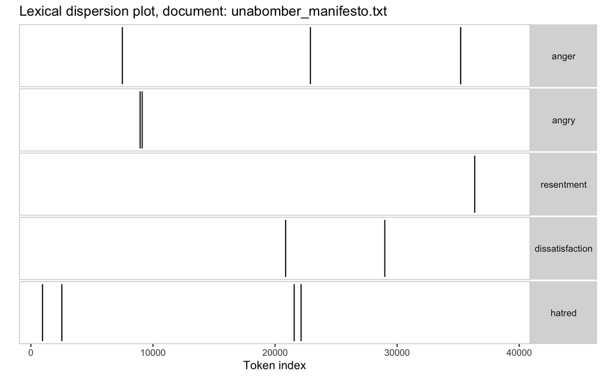

```r
## managed to somehow get on a new version of quanteda, need to specify the
## language
toks <- quanteda::tokens(corpus(unabomb, language = "en"))

# anger plot
textplot_xray(kwic(toks, pattern = c("anger", "angry", "resentment", "dissatisfaction",
    "hatred")), scale = "absolute")
```

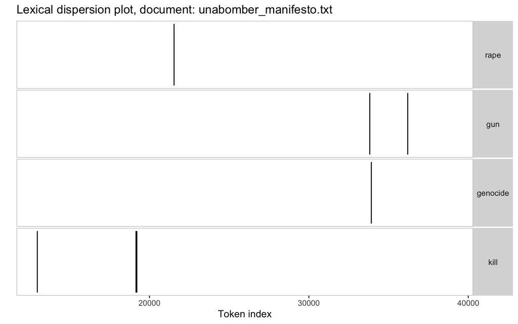

```r
# arousal plot
textplot_xray(kwic(toks, pattern = c("rape", "gun", "genocide", "kill", "terrorist")),
    scale = "absolute")
```

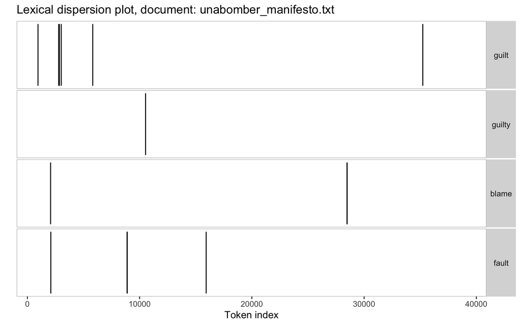

```r
# guilt plot
textplot_xray(kwic(toks, pattern = c("guilt", "guilty", "blame", "fault", "accuse")),
    scale = "absolute")
```

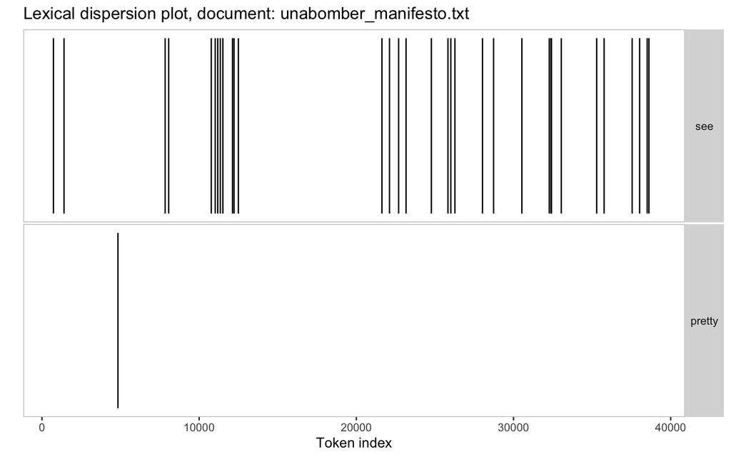

```r
# semantic visualization plot
textplot_xray(kwic(toks, pattern = c("see", "pretty")), scale = "absolute")
```

## Written Report

Overall, there doesn’t seem to be any indication that a “call to action”, based on the above operationalization of words within the Unabomber’s Manifesto scoring high in guilt, anger, arousal, and semantic visualization, at the end of the document. Words seem to be relatively spread out and sparse, with no pattern appearing as to how or why they were written in the order they were written.